# Data Camp / Intro to Time Series Analysis - Chapter 2

Initialize and load the data

Chapter 2 of [Data Camp - Intro to Time Series Analsys](https://www.datacamp.com/courses/introduction-to-time-series-analysis)

### Trends: Variance

#### log()

- Can *linearize* rapid growth
- Can stabalize increasing variance

**Only defined for positive values**

#### diff()

Can remove the linear trend

With the *seasonal difference option* can remove the seasonal component `diff(..., s)`

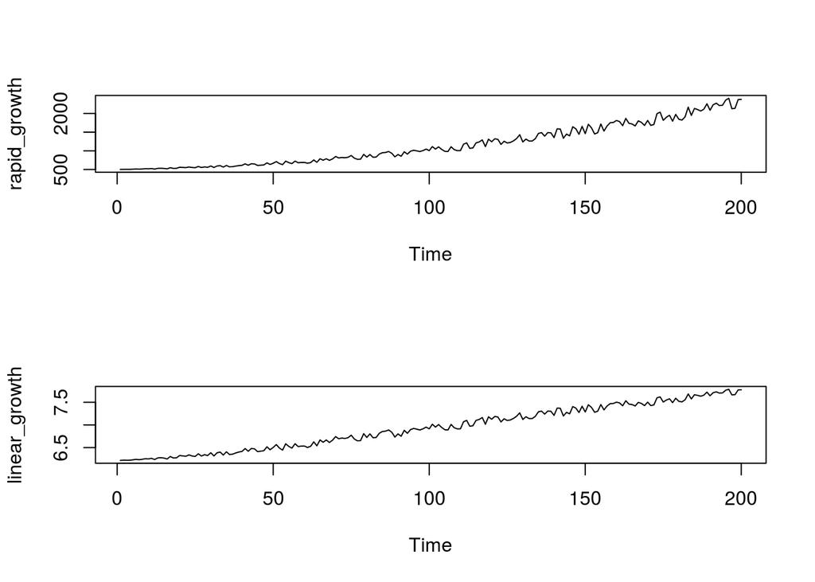

```r
rapid_growth = 500 + (seq(1, 40, length.out = 200) ^ 2) + (runif(200) * seq(1, 400, length.out=200))

par(mfrow=c(2,1))

ts.plot(rapid_growth)

linear_growth = log(rapid_growth)

ts.plot(linear_growth)
```

`diff()` takes the difference between each adjacent value. The result is always *n -1* records. `diff()` can remove a time trend from a series.

Let’s see what happens when we apply to the linear_growth data.

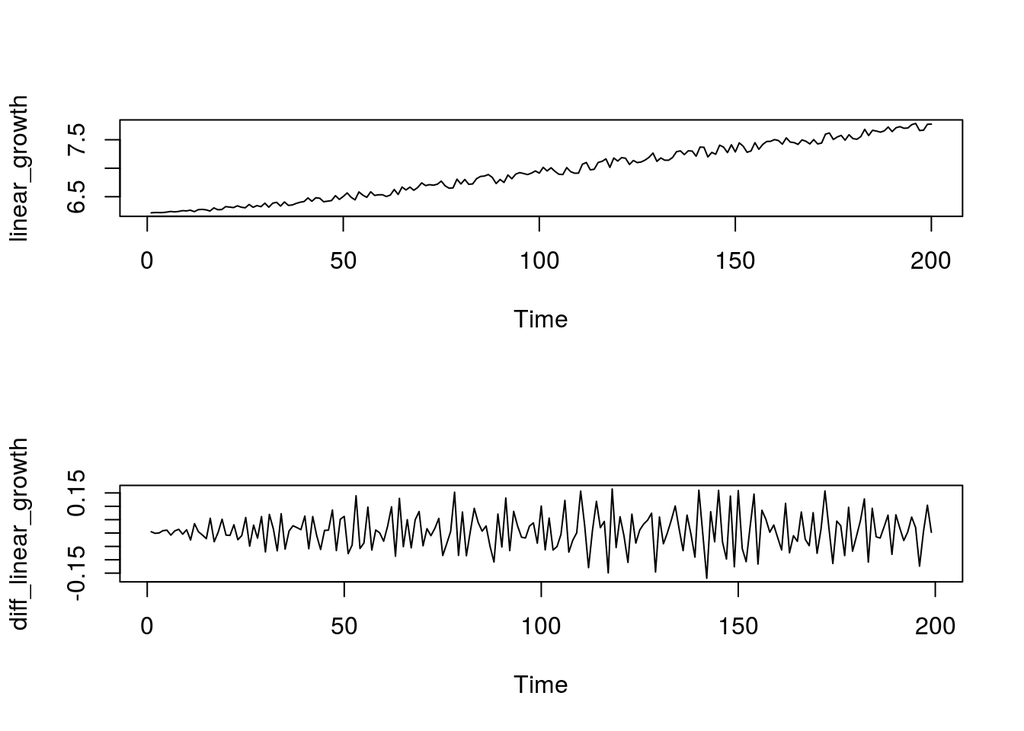

```r
diff_linear_growth = diff(linear_growth)
par(mfrow=c(2,1))
ts.plot(linear_growth)
ts.plot(diff_linear_growth)
```

For data with seasonality the *lag=* option can be applied to remove the seasonality. Let’s see what this can do.

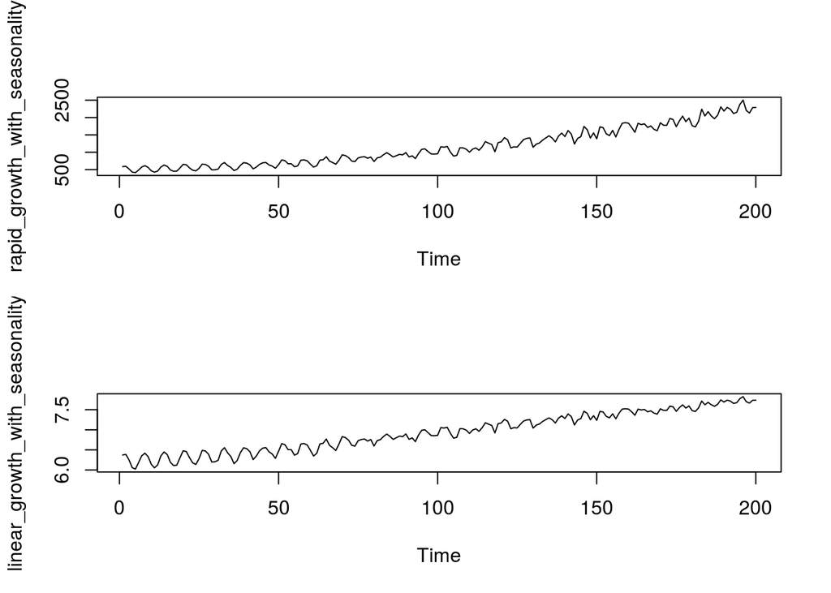

```r
rapid_growth_with_seasonality = rapid_growth + sin(1:200) * 100

par(mfrow=c(2, 1))
# smooth it
linear_growth_with_seasonality = log(rapid_growth_with_seasonality)
linear_growth_with_seasonality_no_trend = diff(linear_growth_with_seasonality)
ts.plot(rapid_growth_with_seasonality)
ts.plot(linear_growth_with_seasonality)
```

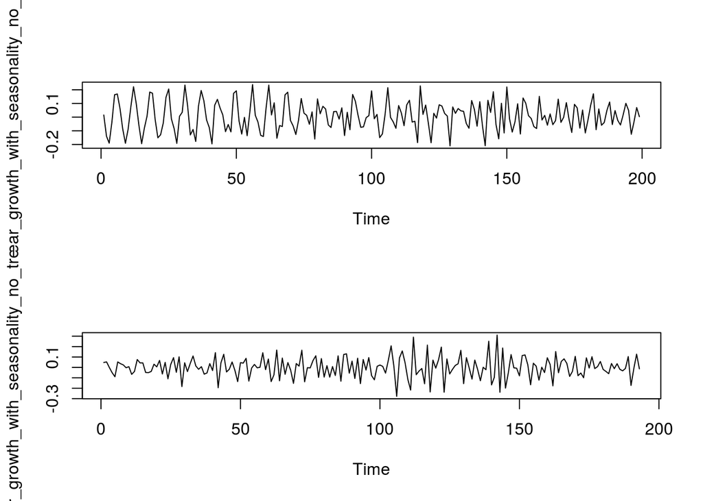

```r
ts.plot(linear_growth_with_seasonality_no_trend)
ts.plot(diff(linear_growth_with_seasonality_no_trend, lag=6))
```

### White Noise model

Simple examle of a *stationary process*.

The *white noise process* has:

- A fixed, constant mean
- A fixed, constant variance
- No correlation over time

If any of these and possibly others, are true it is **NOT** *WN*

- There is a trend in the data
- There is periodocity in the data.
- The variance is changing over time

The `arima.sim()` function can simulate a *WN* dataset. `arima.sim(model=list(order=c(0,0,0)), n=50)`.

#### ARIMA

**A**uto**R**egressive **I**ntegrated **M**oving **A**verage

The `arima()` function will display information about an *ARIMA* dataset including the *mean* (*intercept*), *variance*, *standard error*, etc.

These values can also be obtained directly with the `mean()` and `var()` functions.

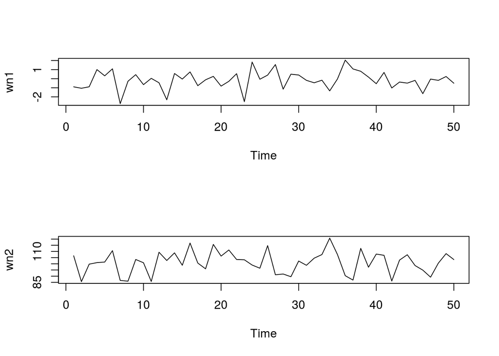

```r
wn1 = arima.sim(model = list(order=c(0,0,0)), n=50)
wn2 = arima.sim(model = list(order=c(0,0,0)), n=50, mean=100, sd=10)

par(mfrow=c(2,1))
ts.plot(wn1)
ts.plot(wn2)
```

```r
arima(wn1, order=c(0,0,0))
```

```
##
## Call:
## arima(x = wn1, order = c(0, 0, 0))
##
## Coefficients:
##       intercept
##         -0.1488
## s.e.     0.1384
##
## sigma^2 estimated as 0.9576:  log likelihood = -69.86,  aic = 143.73
```

```r
mean(wn1)
```

```
## [1] -0.1487935
```

```r
var(wn1)
```

```
## [1] 0.9771432
```

```r
sqrt(var(wn1))
```

```
## [1] 0.9885055
```

```r
arima(wn2, order=c(0,0,0))
```

```
##
## Call:
## arima(x = wn2, order = c(0, 0, 0))
##
## Coefficients:
##       intercept
##        101.1455
## s.e.     1.2458
##
## sigma^2 estimated as 77.6:  log likelihood = -179.74,  aic = 363.47
```

### Random Walk Time Series

- No specified mean or variance
- Strong dependance over time
- Change or ingrements are WN

The *Random Walk Model* is recursively defined as:

*Today = Yesteray + Noise*

$Y_t = Y_{t-1} + \epsilon_t$

where $\epsilon_t$ is mean zero white noise (WN) and $\epsilon_t \longrightarrow \text{diff(Y)}$ is WN

- Simulation requires and initial point $Y_0$
- It has only 1 parm, the WN variance $\sigma_{\epsilon}^2$

The `diff()` of a *Random Walk* series is a *White Noise* series.

It can be defined to include a *drift* variable represented by $c$

$Y_t = c + Y_{t-1} + \epsilon_t$

A *drift* model has 2 parms, the WN variance $\sigma_{\epsilon}^2$ and the constant $c$. Which is just a *Random Walk* series with WN with mean $c$.

The *Random Walk* series is teh cumulative sum (or integration) of a mean zero WN series. This is an **ARIMA(0, 1, 0)** model, where the middle 1 indicates the model’s order of integration is 1.

`arima.sim()` is used to create a *Random Walk* series with *order=c(0,1,0)*.

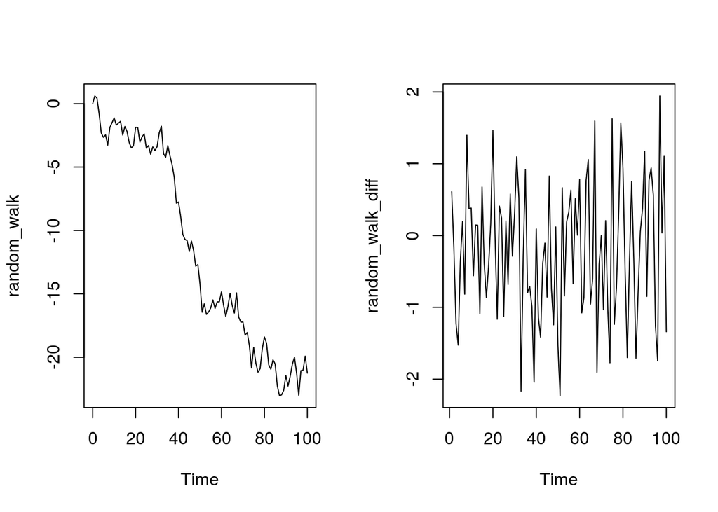

```r
random_walk = arima.sim(model=list(order=c(0,1,0)), n=100)

par(mfrow=c(1,2))

ts.plot(random_walk)

random_walk_diff = diff(random_walk)

ts.plot(random_walk_diff)
```

#### Now with *drift*

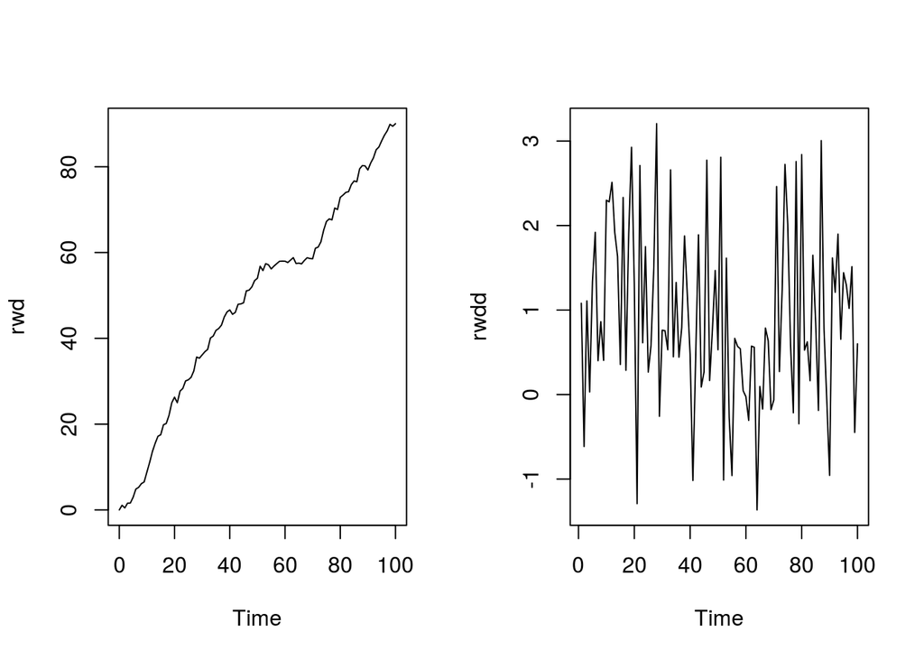

```r
rwd = arima.sim(model=list(order=c(0,1,0)), n=100, mean=1)
par(mfrow=c(1,2))

ts.plot(rwd)

rwdd = diff(rwd)
ts.plot(rwdd)
```

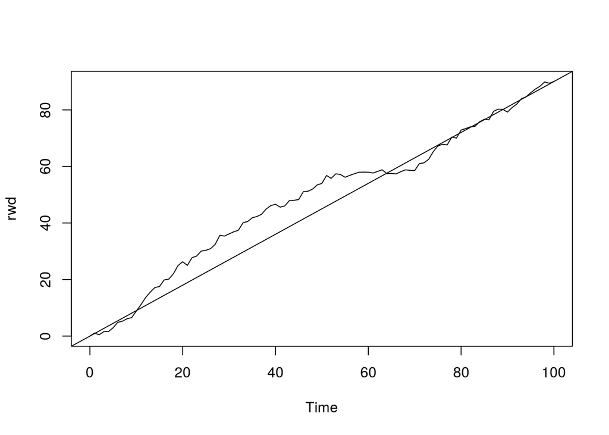

```r
model_wn <- arima(rwdd, order=c(0,0,0))
int_wn = coef(model_wn)

ts.plot(rwd)
abline(0, int_wn)
```

### Stationarity

- Stationary models are parsimonious
- Have distributional stability over time

Observed time series:

- Fluctuate randomly
- But behave similarly from one time period to the next

*See additional slides for more details*

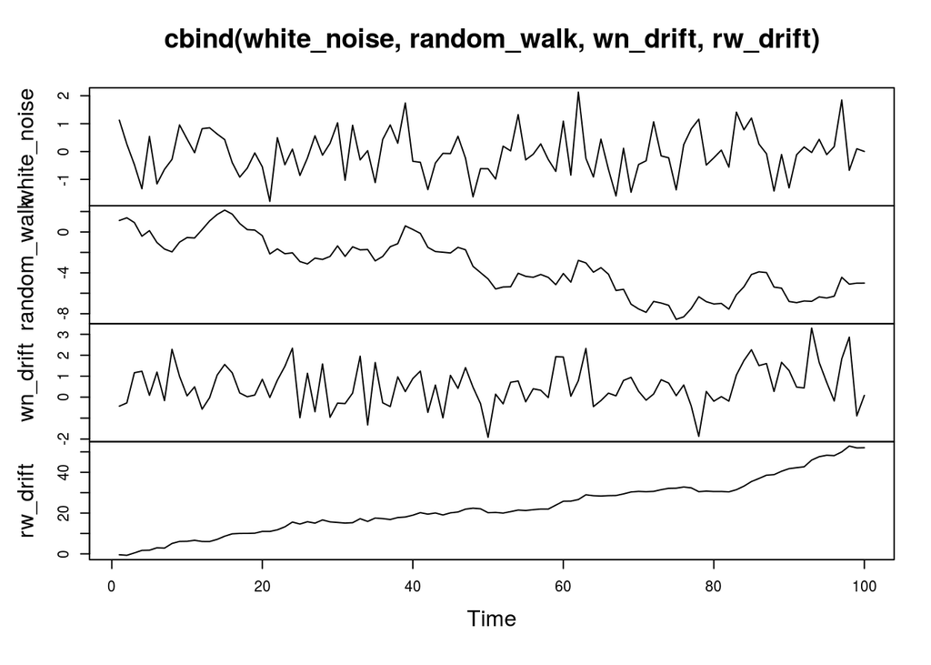

```r
# Use arima.sim() to generate WN data
white_noise <- arima.sim(model=list(order=c(0,0,0)), n=100)

# Use cumsum() to convert your WN data to RW
random_walk <- cumsum(white_noise)

# Use arima.sim() to generate WN drift data
wn_drift <- arima.sim(model=list(order=c(0,0,0)), n=100, mean=0.4)

# Use cumsum() to convert your WN drift data to RW
rw_drift <- cumsum(wn_drift)

# Plot all four data objects
plot.ts(cbind(white_noise, random_walk, wn_drift, rw_drift))
```